# Wind in the Willows Analysis

Shelby Walsh

2/21/2021

# Wind in the Willows: The cheekiest book ever

#### This wild ride, is full of twists, turns and friendships. Sadly this analysis did not turn out the way I invisioned. Time has distorted my memory. Unfortunately, “ass” only appears 11 times, but in my memory and heart, it is the most important word in the entire book.

#### I want to give a shout out to all the fathers out there, who strategically pick when to popcorn your children to read aloud the curse words in this book.

Text was provided by: https://freeditorial.com/en/books/the-wind-in-the-willows/related-books

[figure not shown]

The 4 BEST FRIENDS that anyone could have.

```r
willow_text <- pdf_text("ww.pdf")

willow_tidy <- data.frame(willow_text) %>%
  mutate(text_full = str_split(willow_text, pattern = '\\n')) %>%
  unnest(text_full) %>%
  mutate(text_full = str_trim(text_full))
```

```r
willow_df <- willow_tidy %>%
  slice(-(1:4))


willow_tokens <- willow_df %>%
  unnest_tokens(word, text_full) %>%
  select(-willow_text)

willow_nonstop_words <- willow_tokens %>%
  anti_join(stop_words)

nonstop_counts <- willow_nonstop_words %>%
  count(word)

top_200 <- nonstop_counts %>%
  arrange(-n) %>%
  slice(1:200)

top_50 <- nonstop_counts %>%
  arrange(-n) %>%
  slice(1:50)

top_100 <- nonstop_counts %>%
  arrange(-n) %>%
  slice(1:100)

top_100_wo <- nonstop_counts %>%
  arrange(-n) %>%
  slice(1:100) %>%
  slice(-(1:4))

top_5_words <- nonstop_counts %>%
  arrange(-n) %>%
  slice(1:5)
```

#### The WordCloud below shows the Top 50 words used in “Wind in the Willows”. Mr. Toad, coming in at #1, is of course our wild, load and over the top friend. Rat, while less in your face as Toad, is quite the talkative fellow, coming in at #2. Mole, our sweet, shy naive friend comes in at #3. My personal favorite, Badger comes in at #4. Although in fourth place for mentions, he is #1 in our hearts. River, home, water, animals, friends, boat and bank are all key words in painting a story about our 4 friends who live along a river.

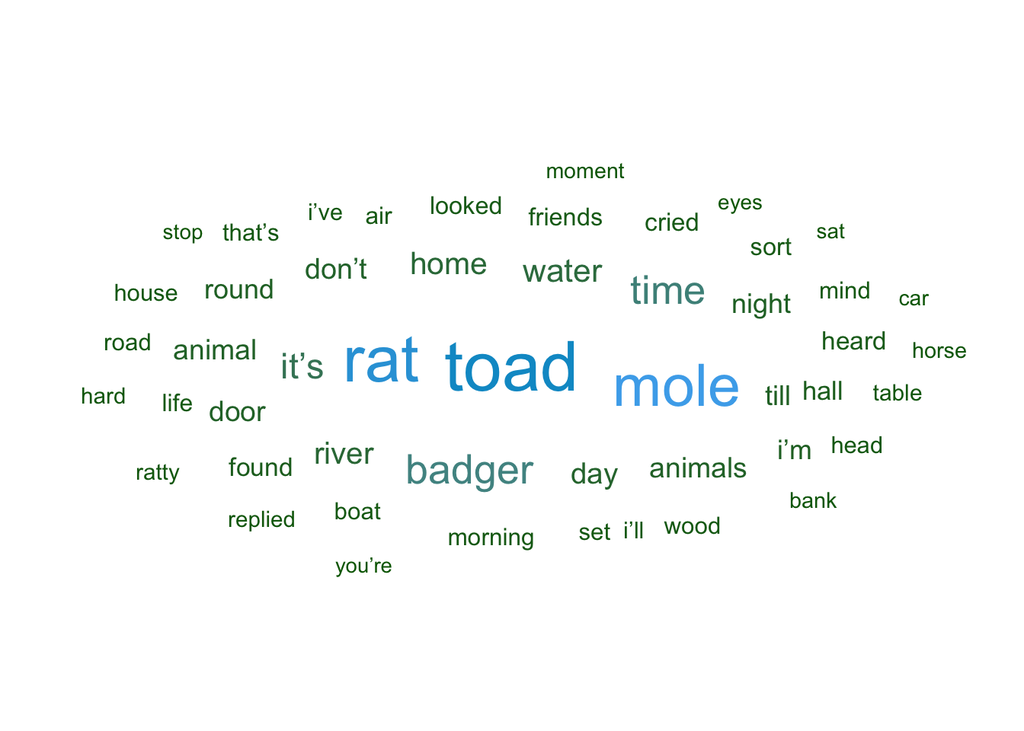

```r
ww_cloud <- ggplot(data = top_100_wo, aes(label = word)) +
  geom_text_wordcloud(aes(color = n, size = n), shape = "diamond") +
  scale_size_area(max_size = 6) +
  scale_color_gradientn(colors = c("darkgreen","blue","purple")) +
  theme_minimal()



ww_cloud_50 <- ggplot(data = top_50, aes(label = word)) +
  geom_text_wordcloud(aes(color = n, size = n), shape = "oval") +
  scale_size_area(max_size = 12) +
  scale_color_gradientn(colors = c("darkgreen","steelblue1","deepskyblue3")) +
  theme_minimal()

ww_cloud_50
```

```r
ww_cloud_100 <- ggplot(data = top_100, aes(label = word)) +
  geom_text_wordcloud(aes(color = n, size = n), shape = "oval") +
  scale_size_area(max_size = 8) +
  scale_color_gradientn(colors = c("darkgreen","steelblue1","deepskyblue3")) +
  theme_minimal()
```

### If this WordCloud intices you, I recommend reading the entire adventure!

## Now let’s look at how the book stacks up against the Afinn Ratings

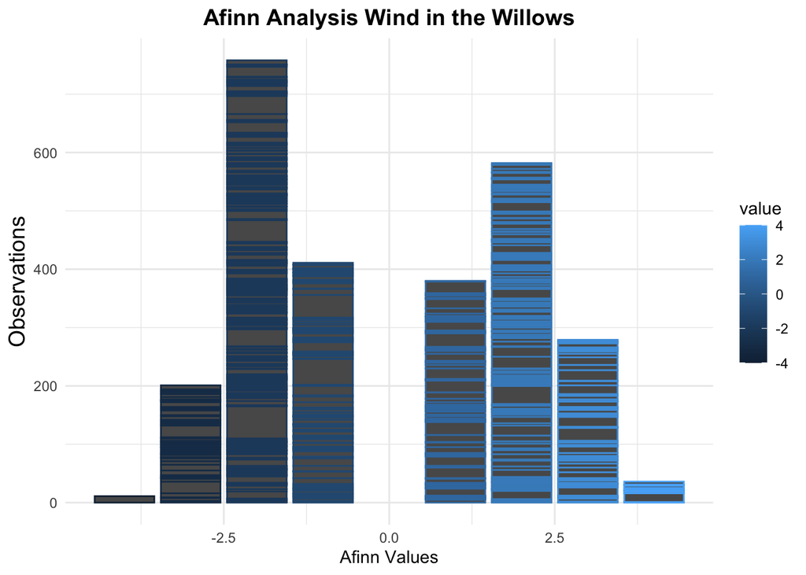

```r
willow_afinn <- willow_nonstop_words %>%
  inner_join(get_sentiments("afinn"))

willow_afinn_count <- willow_afinn %>%
  count(word, value)

willow_afinn_col <- brewer.pal(11, "BrBG")
willow_afinn_col <- colorRampPalette(willow_afinn_col)(713)


willow_nrc <- willow_nonstop_words %>%
  inner_join(get_sentiments("nrc"))

willow_nrc_counts <- willow_nrc %>%
  count(sentiment)

#ggplot(data = willow_nrc_counts, aes(x = sentiment, y = n)) +
  #geom_col() +
  #coord_flip()

ggplot(data = willow_afinn_count, aes(x = value, y = n)) +
  geom_col(aes(color = value)) +
  theme_minimal() +
  labs(x = "Afinn Values",
       y = "Observations",
       title = "Afinn Analysis Wind in the Willows") +
  theme(plot.title = element_text(size = 14,
                                   face = "bold",
        hjust = 0.5),
        axis.title.y = element_text(size = 14))
```

##### As for my original analysis goals, Ass scores a -4 on the Afinn, which is represented by the left most bar on the graph.